# Ant microbes

Ilia Popov

2024-04-18

```r
library(ggplot2)
library(dplyr)
library(stats)
library(psych)
library(readr)
library(tidyr)
library(ggpubr)
library(purrr)
```

```r
main_dir <- dirname(rstudioapi::getSourceEditorContext()$path)
setwd(main_dir)
```

# **Part 1 - pH of the ant goitre**

Questions to be answered:

1. Does the acidity of the goitre depend on feeding?
2. At what point in time is the pH lowest?
3. Does the acidity differ between ants from different colonies?

```r
ant_data_pH <- read.csv("data/Supplementary_Data_Fig.1a.txt", sep="\t")
```

```r
summary(ant_data_pH)
```

```
##    species             colony              worker        workerall
##  Length:231         Length:231         Min.   : 1.00   Min.   :  1.0
##  Class :character   Class :character   1st Qu.:15.00   1st Qu.: 58.5
##  Mode  :character   Mode  :character   Median :29.00   Median :116.0
##                                        Mean   :29.47   Mean   :116.0
##                                        3rd Qu.:44.00   3rd Qu.:173.5
##                                        Max.   :60.00   Max.   :231.0
##      time                 ph
##  Length:231         Min.   :1.500
##  Class :character   1st Qu.:2.500
##  Mode  :character   Median :3.500
##                     Mean   :3.355
##                     3rd Qu.:4.000
##                     Max.   :5.000
```

```r
describe(ant_data_pH)
```

```
##           vars   n   mean    sd median trimmed   mad min max range  skew
## species*     1 231   1.00  0.00    1.0    1.00  0.00 1.0   1   0.0   NaN
## colony*      2 231   3.50  1.72    4.0    3.50  2.97 1.0   6   5.0  0.00
## worker       3 231  29.47 16.86   29.0   29.37 20.76 1.0  60  59.0  0.03
## workerall    4 231 116.00 66.83  116.0  116.00 85.99 1.0 231 230.0  0.00
## time*        5 231   2.52  1.13    3.0    2.53  1.48 1.0   4   3.0 -0.05
## ph           6 231   3.35  0.99    3.5    3.35  1.48 1.5   5   3.5 -0.08
##           kurtosis   se
## species*       NaN 0.00
## colony*      -1.29 0.11
## worker       -1.18 1.11
## workerall    -1.22 4.40
## time*        -1.40 0.07
## ph           -1.09 0.06
```

```r
str(ant_data_pH)
```

```
## 'data.frame':    231 obs. of  6 variables:
##  $ species  : chr  "c.floridanus" "c.floridanus" "c.floridanus" "c.floridanus" ...
##  $ colony   : chr  "C62" "C62" "C62" "C62" ...
##  $ worker   : int  1 2 3 4 5 6 7 8 9 10 ...
##  $ workerall: int  1 2 3 4 5 6 7 8 9 10 ...
##  $ time     : chr  "0+4h" "0+4h" "0+4h" "0+4h" ...
##  $ ph       : num  4 4.5 4 4 3.5 4 3 4.5 4.5 4.5 ...
```

The dataset contains 231 entries for the *Camponotus floridanus* ants, detailing their `colony`, `worker` ID, `time` of pH measurement, and the `pH` values themselves. Here are a few observations and next steps:

**Species Column**: All entries belong to the species *c.floridanus*, so we don’t need to account for different species in our analysis.  
**Time and pH**: The dataset records the pH of the goitre at different time points after feeding (0+4h, 0+24h, 0+48h, 48+4h). We’ll compare these to see if feeding time influences pH.  
**pH Values**: pH ranges from 1.5 to 5.0. The mean pH is approximately 3.35, suggesting a generally acidic environment, which is expected given that formic acid is a primary component of the gland secretion mentioned.

## **Visualisation**

Let’s start with visualizing the pH distribution overall and at each specified time to see if there’s an apparent trend or shift related to feeding times. We’ll use histograms and box plots for these visualizations.

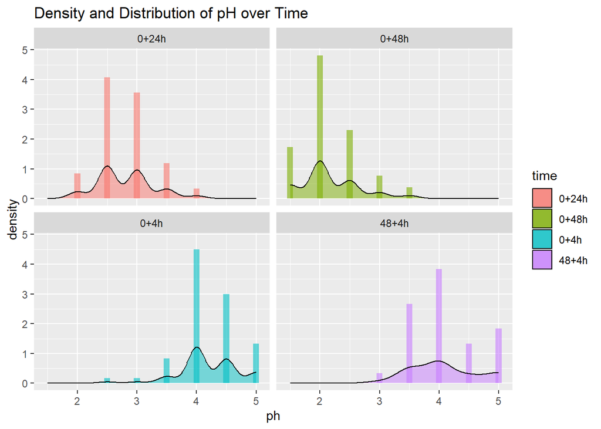

```r
ggplot(ant_data_pH, aes(x = ph, fill = time)) +
  geom_histogram(aes(y = ..density..), binwidth = 0.1, alpha = 0.6, position = "identity") +
  geom_density(alpha = 0.5) +
  facet_wrap(~time) +
  labs(title = "Density and Distribution of pH over Time")
```

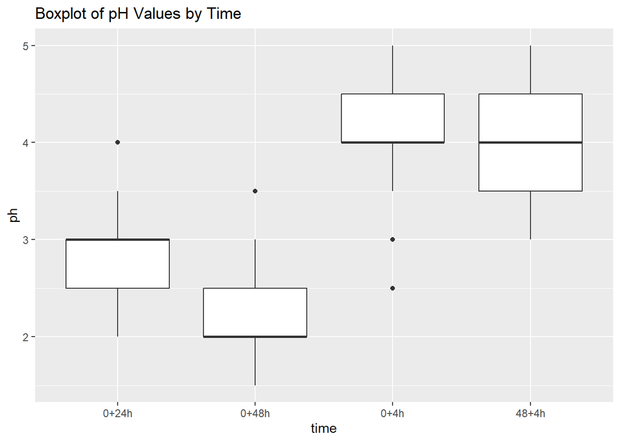

```r
ggplot(ant_data_pH, aes(x = time, y = ph)) +
  geom_boxplot() +
  labs(title = "Boxplot of pH Values by Time")
```

### **Visualisation results**

**Density Plot**: Shows variations in the pH distribution at each time point. We can observe shifts in pH concentration and spread, indicating possible changes due to feeding.  
**Boxplot**: Highlights median values and spread of pH at each time point. Notably, the interquartile range and median values vary, suggesting significant changes in pH levels related to the time post-feeding.  
**Data distribution**: Non-normal.

## **Statistical Analysis**

**Kruskal-Wallis rank sum test for Time Dependency**: We’ll conduct an Kruskal-Wallis rank sum test to test if there are statistically significant differences in pH levels at different times.  
**Kruskal-Wallis rank sum test for Colony Differences**: Another Kruskal-Wallis rank sum test will help determine if pH varies significantly across different ant colonies.  
**Reasons of choice**: Non-normal distributed data. Data with independent observations.

```r
kruskal.test(ph ~ time, data = ant_data_pH)
```

```
##
##  Kruskal-Wallis rank sum test
##
## data:  ph by time
## Kruskal-Wallis chi-squared = 171.17, df = 3, p-value < 2.2e-16
```

```r
kruskal.test(ph ~ colony, data = ant_data_pH)
```

```
##
##  Kruskal-Wallis rank sum test
##
## data:  ph by colony
## Kruskal-Wallis chi-squared = 0.70032, df = 5, p-value = 0.983
```

### **Statistical Analysis Results**

**Kruskal-Wallis rank sum test for Time Dependency**: The results show *p*-value close to zero ( *p* < 0.001 ). This strongly suggests that the pH levels vary significantly across different times, confirming the impact of feeding time on the goitre’s acidity.  
**Kruskal-Wallis rank sum test for Colony Differences**: The Kruskal-Wallis comparing different colonies shows a non-significant result ( *p* = 0.983 ). This implies that the differences in pH levels between colonies are not statistically significant, suggesting that colony does not influence the acidity of the goitre.

# **Part 2 - Immobilisation of ants after feeding**

Questions to be answered:

1. Does the acidity of the goitre depend on the immobilisation of the ant?
2. Does goitre acidity differ between immobilised ants from different colonies?

```r
ant_data_immobilisation <- read.csv("data/Supplementary_Data_Fig.1b.txt", sep="\t")
```

```r
summary(ant_data_immobilisation)
```

```
##    species              worker       treatment               ph
##  Length:45          Min.   : 1.00   Length:45          Min.   :2.0
##  Class :character   1st Qu.: 6.00   Class :character   1st Qu.:2.5
##  Mode  :character   Median :12.00   Mode  :character   Median :3.0
##                     Mean   :11.76                      Mean   :3.2
##                     3rd Qu.:17.00                      3rd Qu.:4.0
##                     Max.   :23.00                      Max.   :5.0
##     colony
##  Length:45
##  Class :character
##  Mode  :character
##
##
##
```

```r
describe(ant_data_immobilisation)
```

```
##            vars  n  mean   sd median trimmed  mad min max range  skew kurtosis
## species*      1 45  1.00 0.00      1    1.00 0.00   1   1     0   NaN      NaN
## worker        2 45 11.76 6.57     12   11.76 8.90   1  23    22  0.00    -1.28
## treatment*    3 45  1.51 0.51      2    1.51 0.00   1   2     1 -0.04    -2.04
## ph            4 45  3.20 0.88      3    3.16 1.48   2   5     3  0.15    -1.10
## colony*       5 45  2.53 1.14      2    2.54 1.48   1   4     3  0.05    -1.46
##              se
## species*   0.00
## worker     0.98
## treatment* 0.08
## ph         0.13
## colony*    0.17
```

```r
str(ant_data_immobilisation)
```

```
## 'data.frame':    45 obs. of  5 variables:
##  $ species  : chr  "c.floridanus" "c.floridanus" "c.floridanus" "c.floridanus" ...
##  $ worker   : int  1 2 3 4 5 6 7 8 9 10 ...
##  $ treatment: chr  "FA+" "FA+" "FA+" "FA+" ...
##  $ ph       : num  2.5 3 3 3 3 2.5 2.5 4 2 2 ...
##  $ colony   : chr  "C219" "C219" "C219" "C219" ...
```

The dataset includes measurements of pH in the goitre of *Camponotus floridanus* ants across different treatments and colonies. Here are some key observations:

**Treatment**: The treatment column, labeled as `treatment`, likely indicates whether ants were immobilized (FA+ suggests presence of formic acid immobilization treatment, if other categories exist we’ll check them).  
**Columns**: Includes `species`, `worker` ID, `treatment`, `pH`, and `colony.`

Let’s first verify the categories under `treatment` to understand the groups we are comparing, then visualize and analyze the data accordingly.

```r
unique(ant_data_immobilisation['treatment'])
```

```
##    treatment
## 1        FA+
## 24       FA-
```

The `treatment` column has two categories:

**FA+**: Ants that were immobilized.  
**FA-**: Ants that were not immobilized.

## **Visualisation**

Let’s start by visualizing the pH distribution for immobilized vs. non-immobilized ants and then proceed with the statistical analysis.

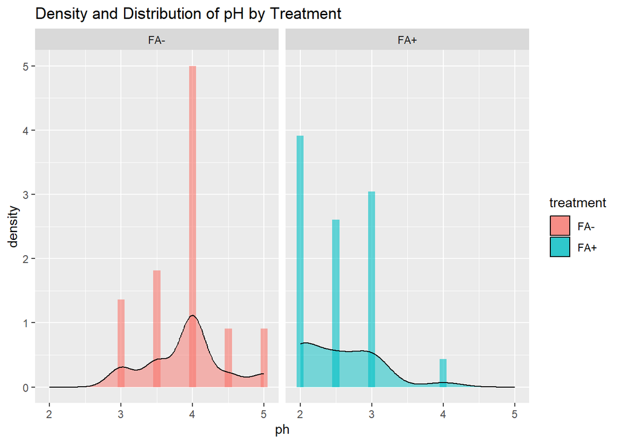

```r
ggplot(ant_data_immobilisation, aes(x = ph, fill = treatment)) +
  geom_histogram(aes(y = ..density..), binwidth = 0.1, alpha = 0.6, position = "identity") +
  geom_density(alpha = 0.5) +
  facet_wrap(~treatment) +
  labs(title = "Density and Distribution of pH by Treatment")
```

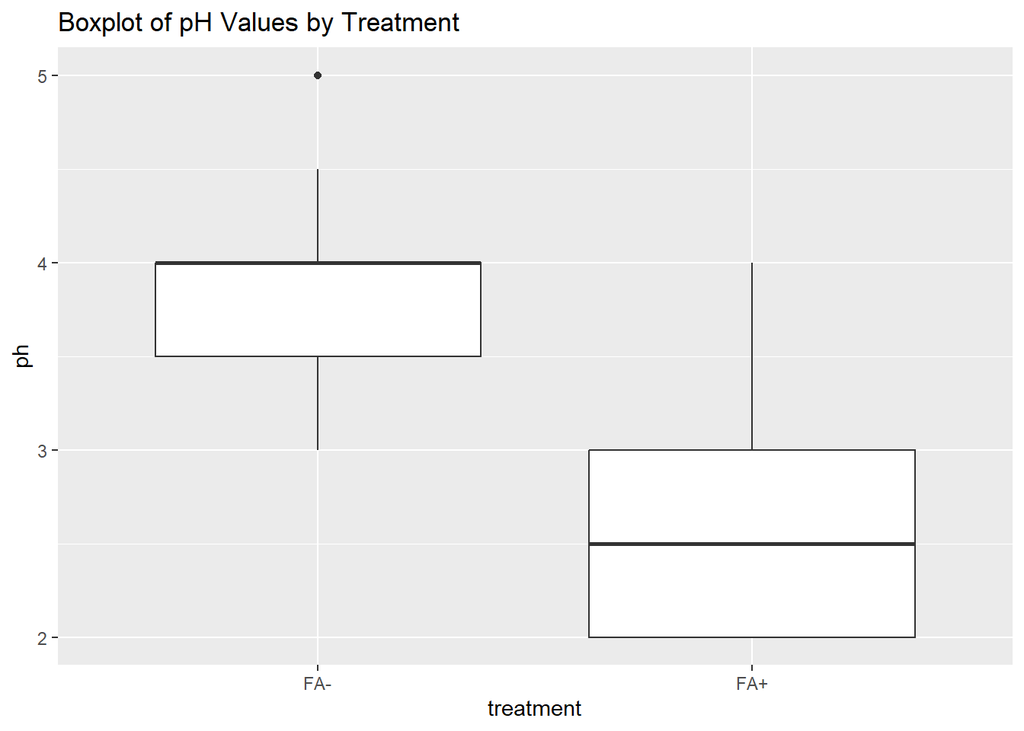

```r
ggplot(ant_data_immobilisation, aes(x = treatment, y = ph)) +
  geom_boxplot() +
  labs(title = "Boxplot of pH Values by Treatment")
```

## **Statistical Analysis**

To substantiate the observations from the visualizations, we’ll perform:

**Mann–Whitney U test** for independent samples to test if the mean pH values significantly differ between the FA+ and FA- groups.  
**Reasons of choice**: Non-normal distributed data. Two independent samples.  
**Kruskal-Wallis rank sum test** to assess pH differences between colonies within immobilized ants (FA+).  
**Reasons of choice**: Non-normal distributed data. Data with independent observations.

```r
fa_plus <- filter(ant_data_immobilisation, treatment == "FA+")
fa_minus <- filter(ant_data_immobilisation, treatment == "FA-")
```

```r
wilcox.test(fa_plus$ph, fa_minus$ph, exact = FALSE)
```

```
##
##  Wilcoxon rank sum test with continuity correction
##
## data:  fa_plus$ph and fa_minus$ph
## W = 23, p-value = 1.035e-07
## alternative hypothesis: true location shift is not equal to 0
```

```r
kruskal.test(ph ~ colony, data = fa_plus)
```

```
##
##  Kruskal-Wallis rank sum test
##
## data:  ph by colony
## Kruskal-Wallis chi-squared = 5.3592, df = 3, p-value = 0.1473
```

# **Part 3 - Do they pass?**

Question to be answered:  
1. Do *Asaia* and *Serratia* bacteria pass from the goitre to the midgut?

```r
ant_data_pass <- read.csv("data/Supplementary_Data_Fig.5ab.txt", sep = "\t")
```

```r
summary(ant_data_pass)
```

```
##    bacteria          gutregion              time            cfu
##  Length:653         Length:653         Min.   : 0.00   Min.   :    0
##  Class :character   Class :character   1st Qu.: 0.50   1st Qu.:    0
##  Mode  :character   Mode  :character   Median : 4.00   Median :    0
##                                        Mean   :10.99   Mean   : 1416
##                                        3rd Qu.:24.00   3rd Qu.:  145
##                                        Max.   :48.00   Max.   :50000
##     colony
##  Length:653
##  Class :character
##  Mode  :character
##
##
##
```

```r
describe(ant_data_pass)
```

```
##            vars   n    mean      sd median trimmed  mad min   max range  skew
## bacteria*     1 653    1.77    0.42      2    1.84 0.00   1     2     1 -1.28
## gutregion*    2 653    1.50    0.50      2    1.50 0.00   1     2     1  0.00
## time          3 653   10.99   15.56      4    7.76 5.93   0    48    48  1.35
## cfu           4 653 1415.63 5801.99      0  145.95 0.00   0 50000 50000  6.10
## colony*       5 653    5.76    3.34      6    5.75 4.45   1    11    10  0.06
##            kurtosis     se
## bacteria*     -0.36   0.02
## gutregion*    -2.00   0.02
## time           0.54   0.61
## cfu           40.95 227.05
## colony*       -1.38   0.13
```

```r
str(ant_data_pass)
```

```
## 'data.frame':    653 obs. of  5 variables:
##  $ bacteria : chr  "asaia" "asaia" "asaia" "asaia" ...
##  $ gutregion: chr  "crop" "crop" "crop" "crop" ...
##  $ time     : num  0 0 0 0 0 0 0 0 0 0 ...
##  $ cfu      : int  10000 20000 20000 40000 3700 9930 30000 40000 10000 10000 ...
##  $ colony   : chr  "C313" "C313" "C313" "C313" ...
```

The dataset consists of 653 entries with the following structure:

**bacteria**: Name of the bacteria (e.g., Asaia, Serratia).  
**gutregion**: Part of the gut where the sample was taken (e.g., crop, midgut).  
**time**: Timepoint of the sample collection in hours.  
**cfu**: Colony-forming units counted.  
**colony**: Colony identifier.

## **Visualisation**

Let’s start with visualizing the CFU distribution in two different gut regions.

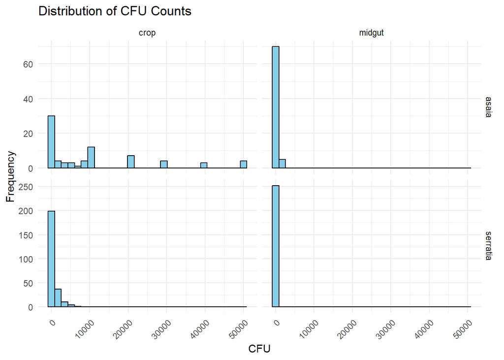

```r
ggplot(ant_data_pass, aes(x = cfu)) +
  geom_histogram(bins = 30, fill = "skyblue", color = "black") +
  facet_grid(bacteria ~ gutregion, scales = "free_y") +
  theme_minimal() +
  labs(title = "Distribution of CFU Counts",
       x = "CFU",
       y = "Frequency") +
  theme(axis.text.x = element_text(angle = 45, hjust = 1))
```

### **Histogram Analysis**

Here are the histograms showing the distribution of colony-forming units (CFU) for both Asaia and Serratia bacteria in different gut regions:

**Asaia in Crop**: The distribution shows a broad range of values with some peaks, indicating variability in the colony counts at different sampling times.  
**Asaia in Midgut**: The counts are significantly lower, mostly near zero, suggesting fewer bacteria pass into or survive in the midgut.  
**Serratia in Crop**: Similar to Asaia, Serratia shows a varied distribution in the crop but generally at lower counts compared to Asaia.  
**Serratia in Midgut**: The counts are very low, similar to Asaia, indicating minimal presence in the midgut.

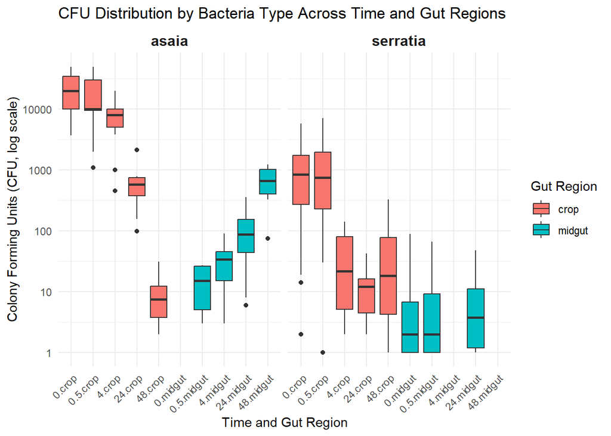

```r
ggplot(ant_data_pass, aes(x = interaction(time, gutregion), y = cfu, fill = gutregion)) +
  geom_boxplot() +
  facet_wrap(~bacteria, scales = "free_x") +
  scale_y_log10() +
  labs(title = "CFU Distribution by Bacteria Type Across Time and Gut Regions",
       x = "Time and Gut Region",
       y = "Colony Forming Units (CFU, log scale)",
       fill = "Gut Region") +
  theme_minimal() +
  theme(axis.text.x = element_text(angle = 45, hjust = 1),
        strip.background = element_blank(),
        strip.text.x = element_text(size = 12, face = "bold"))
```

## **Statistical Analysis**

```r
#Asaia
# I know this solution is not the best one.
# This code can (must) be vectorized, yet all my efforts resulted in wrong results.
# However, this simple code provides correct results. So what's the difference so far!
crop_data_1 <- filter(ant_data_pass, bacteria == "asaia", gutregion == "crop", time == 0)$cfu
midgut_data_1 <- filter(ant_data_pass, bacteria == "asaia", gutregion == "midgut", time == 0)$cfu
crop_data_2 <- filter(ant_data_pass, bacteria == "asaia", gutregion == "crop", time == 0.5)$cfu
midgut_data_2 <- filter(ant_data_pass, bacteria == "asaia", gutregion == "midgut", time == 0.5)$cfu
crop_data_3 <- filter(ant_data_pass, bacteria == "asaia", gutregion == "crop", time == 4.0)$cfu
midgut_data_3 <- filter(ant_data_pass, bacteria == "asaia", gutregion == "midgut", time == 4.0)$cfu
crop_data_4 <- filter(ant_data_pass, bacteria == "asaia", gutregion == "crop", time == 24.0)$cfu
midgut_data_4 <- filter(ant_data_pass, bacteria == "asaia", gutregion == "midgut", time == 24.0)$cfu
crop_data_5 <- filter(ant_data_pass, bacteria == "asaia", gutregion == "crop", time == 48.0)$cfu
midgut_data_5 <- filter(ant_data_pass, bacteria == "asaia", gutregion == "midgut", time == 48.0)$cfu
```

```r
wilcox.test(crop_data_1, midgut_data_1, exact = FALSE)
```

```
##
##  Wilcoxon rank sum test with continuity correction
##
## data:  crop_data_1 and midgut_data_1
## W = 225, p-value = 6.624e-07
## alternative hypothesis: true location shift is not equal to 0
```

```r
wilcox.test(crop_data_2, midgut_data_2, exact = FALSE)
```

```
##
##  Wilcoxon rank sum test with continuity correction
##
## data:  crop_data_2 and midgut_data_2
## W = 225, p-value = 2.082e-06
## alternative hypothesis: true location shift is not equal to 0
```

```r
wilcox.test(crop_data_3, midgut_data_3, exact = FALSE)
```

```
##
##  Wilcoxon rank sum test with continuity correction
##
## data:  crop_data_3 and midgut_data_3
## W = 225, p-value = 3.058e-06
## alternative hypothesis: true location shift is not equal to 0
```

```r
wilcox.test(crop_data_4, midgut_data_4, exact = FALSE)
```

```
##
##  Wilcoxon rank sum test with continuity correction
##
## data:  crop_data_4 and midgut_data_4
## W = 184, p-value = 0.003223
## alternative hypothesis: true location shift is not equal to 0
```

```r
wilcox.test(crop_data_5, midgut_data_5, exact = FALSE)
```

```
##
##  Wilcoxon rank sum test with continuity correction
##
## data:  crop_data_5 and midgut_data_5
## W = 34.5, p-value = 0.001056
## alternative hypothesis: true location shift is not equal to 0
```

```r
#Serratia
# I know this solution is not the best one.
# This code can (must) be vectorized, yet all my efforts resulted in wrong results.
# However, this simple code provides correct results. So what's the difference so far!
crop_data_6 <- filter(ant_data_pass, bacteria == "serratia", gutregion == "crop", time == 0)$cfu
midgut_data_6 <- filter(ant_data_pass, bacteria == "serratia", gutregion == "midgut", time == 0)$cfu
crop_data_7 <- filter(ant_data_pass, bacteria == "serratia", gutregion == "crop", time == 0.5)$cfu
midgut_data_7 <- filter(ant_data_pass, bacteria == "serratia", gutregion == "midgut", time == 0.5)$cfu
crop_data_8 <- filter(ant_data_pass, bacteria == "serratia", gutregion == "crop", time == 4.0)$cfu
midgut_data_8 <- filter(ant_data_pass, bacteria == "serratia", gutregion == "midgut", time == 4.0)$cfu
crop_data_9 <- filter(ant_data_pass, bacteria == "serratia", gutregion == "crop", time == 24.0)$cfu
midgut_data_9 <- filter(ant_data_pass, bacteria == "serratia", gutregion == "midgut", time == 24.0)$cfu
crop_data_10 <- filter(ant_data_pass, bacteria == "serratia", gutregion == "crop", time == 48.0)$cfu
midgut_data_10 <- filter(ant_data_pass, bacteria == "serratia", gutregion == "midgut", time == 48.0)$cfu
```

```r
wilcox.test(crop_data_6, midgut_data_6, exact = FALSE)
```

```
##
##  Wilcoxon rank sum test with continuity correction
##
## data:  crop_data_6 and midgut_data_6
## W = 3396, p-value < 2.2e-16
## alternative hypothesis: true location shift is not equal to 0
```

```r
wilcox.test(crop_data_7, midgut_data_7, exact = FALSE)
```

```
##
##  Wilcoxon rank sum test with continuity correction
##
## data:  crop_data_7 and midgut_data_7
## W = 3279, p-value = 5.6e-16
## alternative hypothesis: true location shift is not equal to 0
```

```r
wilcox.test(crop_data_8, midgut_data_8, exact = FALSE)
```

```
##
##  Wilcoxon rank sum test with continuity correction
##
## data:  crop_data_8 and midgut_data_8
## W = 1920, p-value = 0.04371
## alternative hypothesis: true location shift is not equal to 0
```

```r
wilcox.test(crop_data_9, midgut_data_9, exact = FALSE)
```

```
##
##  Wilcoxon rank sum test with continuity correction
##
## data:  crop_data_9 and midgut_data_9
## W = 1413.5, p-value = 0.695
## alternative hypothesis: true location shift is not equal to 0
```

```r
wilcox.test(crop_data_10, midgut_data_10, exact = FALSE)
```

```
##
##  Wilcoxon rank sum test with continuity correction
##
## data:  crop_data_10 and midgut_data_10
## W = 199.5, p-value = 0.1629
## alternative hypothesis: true location shift is not equal to 0
```

### **Statistical Analysis Results**

**Asaia Results**:  
0 hours: U Statistic = 225, P-value ≈ 0.00000066 (Significant)  
0.5 hours: U Statistic = 225, P-value ≈ 0.00000208 (Significant)  
4 hours: U Statistic = 225, P-value ≈ 0.00000306 (Significant)  
24 hours: U Statistic = 184, P-value ≈ 0.00322 (Significant)  
48 hours: U Statistic = 34.5, P-value ≈ 0.00106 (Significant)  
**Serratia Results**:  
0 hours: U Statistic = 3396, P-value ≈ 0.0000000000000000347 (Significant)  
0.5 hours: U Statistic = 3279, P-value ≈ 0.00000000000000056 (Significant)  
4 hours: U Statistic = 1920, P-value ≈ 0.0437 (Significant)  
24 hours: U Statistic = 1413.5, P-value ≈ 0.695 (Not significant)  
48 hours: U Statistic = 199.5, P-value ≈ 0.1629 (Not significant)

For *Asaia*, there is a statistically significant difference between the crop and midgut CFU counts at all measured time points. This suggests that there is a consistent difference in the bacterial population between these two gut regions across time, supporting the hypothesis that Asaia does not maintain equal populations between the crop and the midgut.  
For *Serratia*, significant differences are observed in the early time points (0, 0.5, and 4 hours), indicating initial differences in bacterial populations between the crop and the midgut. However, at 24 and 48 hours, the p-values indicate no significant differences, which might suggest that over time, any initial differences in population may equalize or become less distinct.

# **References**

The following packages must be installed to work with the dataset:

```r
knitr::write_bib(c("ggplot2", "dplyr", "stats", "psych",
                   "readr", "tidyr", "ggpubr",
                   "purrr"), file = "packages.bib")
```